# Naive Bayes and k-fold crossvalidation

#Introduction

This tutorial will use a heart risk dataset. First we load the data set and briefly inspect it. Note: that it contains both qual and quant data.

```r
#setwd("C:\\Users\\jerem\\Google Drive\\Online\\iCuse\\IST707\\Week7")

filename="LabeledDataRiskHeart.csv"
RiskDF <- read.csv(filename, header = TRUE, stringsAsFactors = TRUE)
(head(RiskDF))
```

```
##    Label Gender Cholesterol MaritalStatus Weight Height StressLevel
## 1   Risk      M         251             S    267     70           5
## 2 NoRisk      F         105             M    103     62           1
## 3 Medium      M         156             S    193     72           3
## 4 NoRisk      F         109             M    100     63           2
## 5   Risk      M         198             S    210     70           4
## 6   Risk      F         189             S    189     64           3
```

```r
(str(RiskDF))
```

```
## 'data.frame':    32 obs. of  7 variables:
##  $ Label        : Factor w/ 3 levels "Medium","NoRisk",..: 3 2 1 2 3 3 2 1 3 2 ...
##  $ Gender       : Factor w/ 2 levels "F","M": 2 1 2 1 2 1 1 1 2 2 ...
##  $ Cholesterol  : int  251 105 156 109 198 189 121 134 250 118 ...
##  $ MaritalStatus: Factor w/ 2 levels "M","S": 2 1 2 1 2 2 2 1 2 1 ...
##  $ Weight       : int  267 103 193 100 210 189 105 125 156 190 ...
##  $ Height       : int  70 62 72 63 70 64 65 60 69 71 ...
##  $ StressLevel  : int  5 1 3 2 4 3 1 2 5 3 ...
```

```r
(nrow(RiskDF))
```

```
## [1] 32
```

```r
RiskDF$StressLevel<-as.factor(RiskDF$StressLevel)
RiskDF$Cholesterol<-as.numeric(RiskDF$Cholesterol)
RiskDF$Weight<-as.numeric(RiskDF$Weight)
RiskDF$Height<-as.numeric(RiskDF$Height)
(str(RiskDF))
```

```
## 'data.frame':    32 obs. of  7 variables:
##  $ Label        : Factor w/ 3 levels "Medium","NoRisk",..: 3 2 1 2 3 3 2 1 3 2 ...
##  $ Gender       : Factor w/ 2 levels "F","M": 2 1 2 1 2 1 1 1 2 2 ...
##  $ Cholesterol  : num  251 105 156 109 198 189 121 134 250 118 ...
##  $ MaritalStatus: Factor w/ 2 levels "M","S": 2 1 2 1 2 2 2 1 2 1 ...
##  $ Weight       : num  267 103 193 100 210 189 105 125 156 190 ...
##  $ Height       : num  70 62 72 63 70 64 65 60 69 71 ...
##  $ StressLevel  : Factor w/ 5 levels "1","2","3","4",..: 5 1 3 2 4 3 1 2 5 3 ...
```

# Crossvalidation

Next we set up or experimental evaluation. We will use k-fold crossvalidation. The split function helps to facilitate the partitioning of the data set which determines the k folds.

```r
###############################################################
#############  Create k-folds for k-fold validation ###########
###############################################################


# Number of observations
N <- nrow(RiskDF)
# Number of desired splits
kfolds <- 2
# Generate indices of holdout observations
# Note if N is not a multiple of folds you will get a warning, but is OK.
holdout <- split(sample(1:N), 1:kfolds)
```

# Experimental Validation

Running k-fold crossvalidation requires that we run k trials. This is facilitated using a for loop that iterates k times. During each iteration, k-1 partition are assigned to the training set and the remaining partition is the test set.

## Naive Bayes

During each iteration a Naive Bayes model is trained and tested using naiveBayes and predict, respectively.

```r
#####  Run training and Testing for each of the k-folds
AllResults<-list()
AllLabels<-list()
for (k in 1:kfolds){

  RiskDF_Test=RiskDF[holdout[[k]], ]
  RiskDF_Train=RiskDF[-holdout[[k]], ]
  ## View the created Test and Train sets
  (head(RiskDF_Train))
  (table(RiskDF_Test$Label))

  ## Make sure you take the labels out of the testing data
  (head(RiskDF_Test))
  RiskDF_Test_noLabel<-RiskDF_Test[-c(1)]
  RiskDF_Test_justLabel<-RiskDF_Test$Label
  (head(RiskDF_Test_noLabel))


  #### e1071
  ## formula is label ~ x1 + x2 + .  NOTE that label ~. is "use all to create model"
  NB_e1071<-naiveBayes(Label~., data=RiskDF_Train, na.action = na.pass)
  NB_e1071_Pred <- predict(NB_e1071, RiskDF_Test_noLabel)
  NB_e1071

  ## Accumulate results from each fold
  AllResults<- c(AllResults,NB_e1071_Pred)
  AllLabels<- c(AllLabels, RiskDF_Test_justLabel)

}
```

# Results

Results are presented in tabular form below. You can easily create a confusion matrix from this data – try it!

```r
### end crossvalidation -- present results for all folds
table(unlist(AllResults),unlist(AllLabels))
```

```
##
##      1  2  3
##   1  5  3  2
##   2  1  8  0
##   3  3  0 10
```

# Another NB library

Below is another NB package you can try. It is similar but also has some fun visualizations.

Laplace Modeling. Try varying the laplace parameter … what happens? Review the PPT to determine why and explain your results.

```r
## using naivebayes package
## https://cran.r-project.org/web/packages/naivebayes/naivebayes.pdf

##Also see
##https://www.rdocumentation.org/packages/naivebayes/versions/0.9.2/topics/naive_bayes
## Try varying the Laplace value ... how does this affect the results???


#prior <- as.vector(c(0, .4, .6) )

NB_object<- naive_bayes(Label~., laplace = 0 , data=RiskDF_Train)
NB_prediction<-predict(NB_object, RiskDF_Test_noLabel , type = c("class"))
head(predict(NB_object, RiskDF_Test_noLabel, type = "prob"))
```

```
##            Medium        NoRisk         Risk
## [1,] 8.946961e-01  1.811366e-21 1.053039e-01
## [2,] 4.224734e-12 1.495789e-126 1.000000e+00
## [3,] 3.727679e-03  9.962665e-01 5.856113e-06
## [4,] 9.660435e-01  3.123373e-02 2.722803e-03
## [5,] 5.091660e-04  9.994904e-01 4.011732e-07
## [6,] 8.699467e-01  3.685753e-08 1.300533e-01
```

```r
table(NB_prediction,RiskDF_Test_justLabel)
```

```
##              RiskDF_Test_justLabel
## NB_prediction Medium NoRisk Risk
##        Medium      3      3    1
##        NoRisk      0      4    0
##        Risk        1      0    4
```

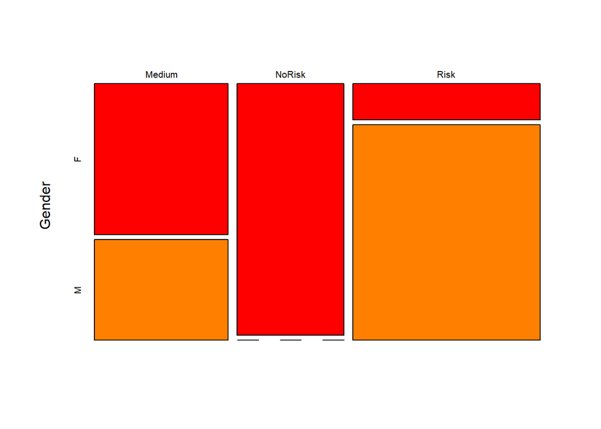

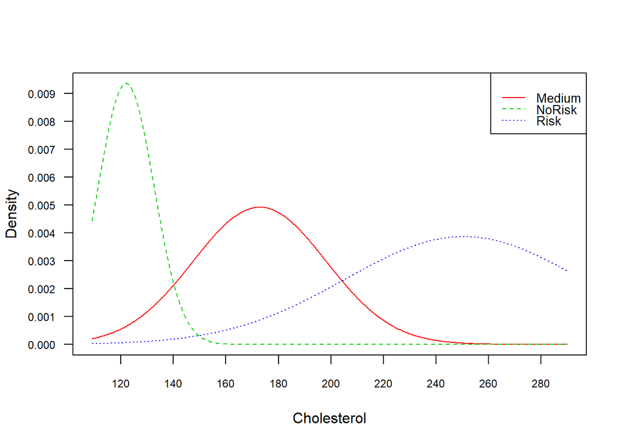

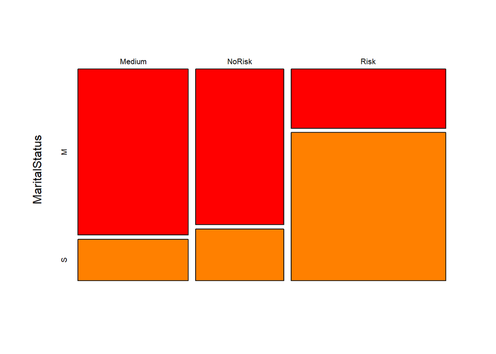

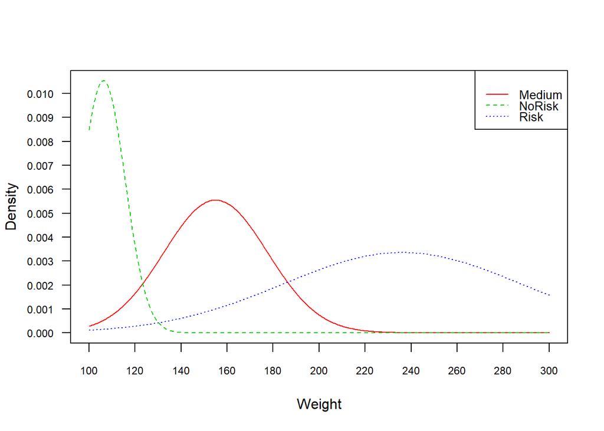

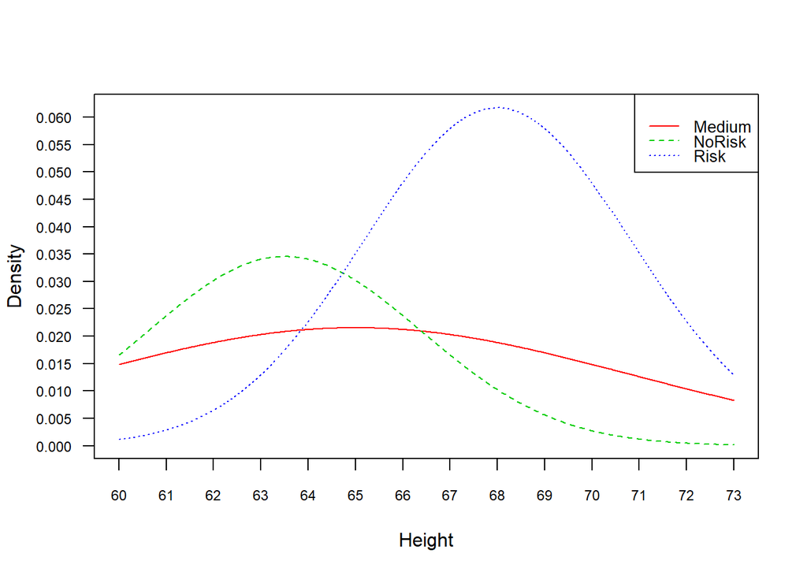

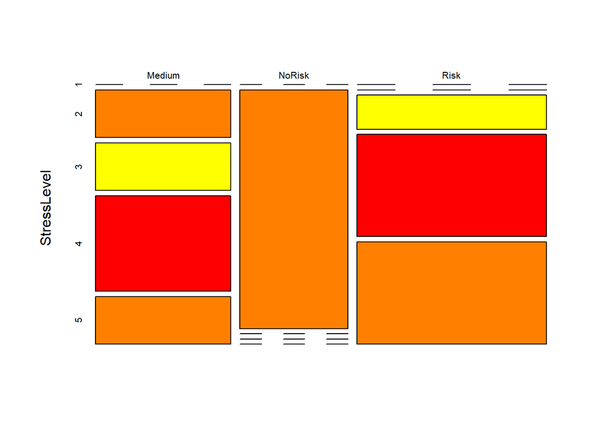

```r
plot(NB_object, legend.box = TRUE)
```